Dishant Sukhwal  
2205162  
disukh@utu.fi  
18/11/2022

# Data Analysis and Knowledge Discovery: Exercise 2, Supervised learning

The previous exercise was about *data understanding* and *data preparation*, which formed the basis for the modeling phase of the data mining process. Many modeling techniques make assumptions about data so the exploration and preparation phases can't be ignored. Now, as we have checked the validity of data and familiarized ourselves with it, we can move on to the next stage of the Cross-Industry Standard Process for Data Mining (CRISP-DM) which is *modeling*.

The questions to be answered at this stage could be for example:

- What kind of model architecture best fits our data?
- How well does the model perform technically?
- Could we improve that performance?
- How the performance of the model is evaluated?

*Machine learning* is a subfield of artificial intelligence which provides automatic, objective and data-driven techniques for modeling the data. The machine learning algorithms aim to learn from data to make predictions. The two main branches of it are *supervised learning* and *unsupervised learning*. In this exercise, we are going to use the former -- *supervised learning* -- for classification and regression tasks.

For classification, data remains the same as in the previous exercise, but I've already cleaned it up for you. Some data pre-processing steps are still required to ensure that it's in an appropriate format, so that models can learn something from it. Even though we are not doing any major data exploration nor data preparation here this time, *you should **never** forget it in your future data analyses*.

**General guidance for exercises**

- Answer **all** questions below, even if you can't get your script to fully work.
- Write clear and easily readable code, and include explanations what your code does
- Make informative illustrations: include labels for x and y axes, legends and captions for your plots.
- You can add more code and markup cells, as long as the flow of the notebook stays readable and logical.
- Before saving the ipynb file (and possible printing) run: "Restart & Run all", to make sure you return a file that works as expected.
- Grading: *Fail*/*Pass*/*Pass with honors* (+1)
- +1 bonus point (grading *Pass with honors*) requires a **completely** correct solution and also thorough analysis.
- If you encounter problems, Google first. If you can't find an answer to the problem, don't hesitate to ask in the Moodle discussion or directly via moodle chat or email from the course assistants.
- Note! Don't leave it to the last moment! No feedback service during weekends.

**The deadline is 28 November at 18:00**. Late submissions will not be accepted unless there is a valid excuse for extending the deadline before the due date.

### Gather **all** packages needed for this notebook here:

You can use other packages as well, but this excercise can be completed with those below.

```python
import numpy as np
import pandas as pd
import scipy.stats as stats
import seaborn as sns
import matplotlib.pyplot as plt

# Machine learning package - scikit-learn
from sklearn import metrics
from sklearn.preprocessing import StandardScaler
from sklearn.model_selection import train_test_split, cross_val_score, LeaveOneOut, GridSearchCV
from sklearn.neighbors import KNeighborsClassifier, KNeighborsRegressor
from sklearn.linear_model import Ridge
from sklearn.metrics import classification_report, roc_curve, roc_auc_score, RocCurveDisplay, auc, mean_absolute_error

# Show the plots inline in the notebook
%matplotlib inline
```

## 1. Classification using k-nearest neighbors

We start exploring the world of data modeling by using **K-Nearest Neightbors (k-NN) algorithm**. The k-NN algorithm is one of the classic supervised machine learning algorithms. It assumes that similar points are close to each other.

In our case, we'll use the k-NN algorithm to **predict the presence of cardiovascular disease** using all the other variables as **features** in the given data set. So, the target variable is **cardio**.

But first, we need data for the task. The code for loading the data into the environment is provided for you. The code should work, but make sure, that you have the csv file of the data in the same directory where you have this notebook file.

***Exercise 1 A)***

Print the first 10 rows to check that everything is ok with the created dataframe.

*note: as said, the data remains the same, but cholesterol has been one-hot-encoded for you already. There's also a new variable gluc (about glucose levels), which is one-hot-encoded for you. It has the similar values as cholesterol originally does [normal, at risk, elevated]. Also, binary variables have been changed to [0,1] values.*

```python
### Loading code provided
# ------------------------------------------------------
# The data file should be at the same location than the
# exercise file to make sure the following lines work!
# Otherwise, fix the path.
# ------------------------------------------------------

# Path for the data
data_path = 'ex2_cardio_data.csv'

# Create a dataframe
cardio_data = pd.read_csv(data_path, dtype='int')
```

```python
### Code - 10 first row
cardio_data.head(10)
```

|  | age | sex | height | weight | ap_hi | ap_lo | smoke | alco | active | cardio | cholesterol_at_risk | cholesterol_elevated | cholesterol_normal | gluc_at_risk | gluc_elevated | gluc_normal |
| --- | --- | --- | --- | --- | --- | --- | --- | --- | --- | --- | --- | --- | --- | --- | --- | --- |
| 0 | 22767 | 0 | 162 | 75 | 120 | 80 | 0 | 0 | 1 | 0 | 0 | 0 | 1 | 0 | 0 | 1 |
| 1 | 19102 | 0 | 164 | 80 | 140 | 90 | 0 | 0 | 1 | 0 | 0 | 0 | 1 | 0 | 0 | 1 |
| 2 | 23251 | 0 | 155 | 76 | 130 | 80 | 0 | 0 | 1 | 0 | 0 | 0 | 1 | 0 | 1 | 0 |
| 3 | 22651 | 1 | 169 | 65 | 120 | 80 | 0 | 0 | 1 | 0 | 0 | 0 | 1 | 0 | 0 | 1 |
| 4 | 21770 | 1 | 171 | 67 | 160 | 100 | 0 | 0 | 0 | 1 | 0 | 0 | 1 | 0 | 0 | 1 |
| 5 | 14651 | 1 | 170 | 70 | 120 | 80 | 0 | 0 | 1 | 0 | 0 | 0 | 1 | 0 | 0 | 1 |
| 6 | 17391 | 0 | 152 | 65 | 110 | 70 | 0 | 0 | 1 | 0 | 0 | 0 | 1 | 0 | 0 | 1 |
| 7 | 14792 | 0 | 165 | 65 | 120 | 70 | 0 | 0 | 1 | 0 | 0 | 0 | 1 | 0 | 0 | 1 |
| 8 | 15982 | 1 | 180 | 81 | 110 | 70 | 1 | 0 | 1 | 0 | 0 | 0 | 1 | 0 | 0 | 1 |
| 9 | 19589 | 0 | 156 | 60 | 120 | 90 | 0 | 0 | 1 | 0 | 0 | 0 | 1 | 0 | 0 | 1 |

We have the data so let's make use of it.

To teach the k-NN algorithm (or any kind of machine learning algorithm) to recognize patterns, we are going to need **training data**. But to test how well a model possibly learned those patterns, we'll need **test data** which is new and unseen for the trained model. Keep in mind that the test set is not shown for the model before we are actually done with training.

So, to **find the estimate for the performance of a model**, we are going to use this **train-test split**. "Split" because we literally split the data into two sets.

Sometimes stratification needs to be considered. It can be used to ensure that train and test sets contain the same proportions of samples of each target class as the original data set.

***Exercise 1 B)***

Gather the features as an array `features`, and the target variable as an array `labels`. Produce training and test data. Divide the data **randomly** into training (80%) and test (20%) sets.

- Would it be a good idea to use stratification? **Explain** your decision.

```python
### Code - Train-test split
features = cardio_data.drop('cardio', axis=1)
labels = cardio_data['cardio']

training_features, testing_features, training_labels, testing_lables = train_test_split(features, labels, test_size=0.2, stratify=labels)
```

```python
print(f'\nOriginal Labels:- \n{cardio_data.cardio.value_counts()} \n')
print(f'Training Labels:- \n{training_labels.value_counts()} \n')
print(f'Testing Labels:- \n{testing_lables.value_counts()} \n')
```

```
Original Labels:-
0    713
1    287
Name: cardio, dtype: int64

Training Labels:-
0    570
1    230
Name: cardio, dtype: int64

Testing Labels:-
0    143
1     57
Name: cardio, dtype: int64
```

***Yes, we can should use startification, Because it will ensure that the testing and training dataset that we get after splitting contains the labels in same proportion as in the original dataset. In our case, 71.3% observations do not have cardiovascular disease and the remaining 28.7% observations have a cardiovascular disease. It can be observed that this proportion is preserved in both training and testing lables as we used stratification.***

***Exercise 1 C)***

Scale the numeric features.

- Remind yourself briefly why you need this step.
- What can you say about scaling especially from the perspective of the k-NN algorithm?

*tip: You should now have* *two** variables where you have the features divided into. Don't forget to scale the test data. Some good information about preprocessing and how to use it for train and test data can be found https://scikit-learn.org/stable/modules/preprocessing.html.*

```python
### Code - Standardization
# selecting numeric features from training and testing set
numeric_feature_columns = ['age','height','weight','ap_hi','ap_lo']
training_numeric_features = training_features[numeric_feature_columns]
testing_numeric_features = testing_features[numeric_feature_columns]

# scaling the numeric features in training and testing set
scaler = StandardScaler()
standardized_training_features = pd.DataFrame(scaler.fit_transform(training_numeric_features), columns=numeric_feature_columns)
standardized_testing_features = pd.DataFrame(scaler.fit_transform(testing_numeric_features), columns=numeric_feature_columns)

# merging non numeric features with the new scaled training and testing set
standardized_training_features = pd.concat([standardized_training_features, training_features.loc[:, ~training_features.columns.isin(numeric_feature_columns)].reset_index()], axis=1)
standardized_testing_features = pd.concat([standardized_testing_features, testing_features.loc[:, ~testing_features.columns.isin(numeric_feature_columns)].reset_index()], axis=1)

# setting the original index
standardized_training_features.set_index('index', inplace=True)
standardized_testing_features.set_index('index', inplace=True)
```

***Data with different scales can influence each other, using standardization, data with a high scale and lower scale are transformed to have a same scale so that it can be analysed easily. In our case, 'age' has a higher scale as compared to the other numeric features, therefore, it is important to scale the features. Since K-NN follows a distance based approach, I think scaling can improve the performance of the model.***

It's time for us to train the model!

***Exercise 1 D)***

Train a k-NN model with $k=3$. Print out the confusion matrix.

- What can you say about the confusion matrix?
- How does the model perform with the different classes? Where do you think the differences come from?
- What is the total classification accuracy? How would you interpret it?
- Perform also the following:
  - Make 1000 **different** train and test set splits.
  - Run the k-NN model (with $k=3$) for each split and save its accuracy.
  - Plot accuracies in a histogram.
  - Discuss your results

*tip: `sklearn.metrics.classification_report` is a great way to build up a text report showing the main classification metrics*

```python
### Code - kNN classifier
knn = KNeighborsClassifier(n_neighbors=3)
knn.fit(standardized_training_features, training_labels)
knn.score(standardized_testing_features, testing_lables)
```

```
0.75
```

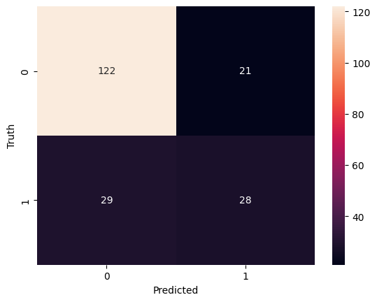

```python
from sklearn.metrics import confusion_matrix

predicted_labels = knn.predict(standardized_testing_features)
matrix = confusion_matrix(testing_lables, predicted_labels)

sns.heatmap(matrix, annot=True, fmt='g')
plt.xlabel('Predicted')
plt.ylabel('Truth')
```

```python
print(classification_report(testing_lables, predicted_labels))
```

```
              precision    recall  f1-score   support

           0       0.81      0.85      0.83       143
           1       0.57      0.49      0.53        57

    accuracy                           0.75       200
   macro avg       0.69      0.67      0.68       200
weighted avg       0.74      0.75      0.74       200
```

```python
# creating standardized feature and extracting labels from whole data
standardized_features = pd.concat([pd.DataFrame(scaler.fit_transform(cardio_data[numeric_feature_columns]), columns=numeric_feature_columns), cardio_data.loc[:, ~cardio_data.columns.isin(numeric_feature_columns)]], axis=1)
labels_n = standardized_features['cardio']
standardized_features.drop('cardio', axis=1, inplace=True)
```

```python
### Code - 1000 different train-test-splits
accuracies = []

for i in range(1000):
    standardized_training_features_n, standardized_testing_features_n, training_labels_n, testing_lables_n = train_test_split(standardized_features, labels_n, test_size=0.2, stratify=labels)
    knn.fit(standardized_training_features_n, training_labels_n)
    accuracies.append(knn.score(standardized_testing_features_n, testing_lables_n))
```

```python
np.mean(accuracies)
```

```
0.7581100000000002
```

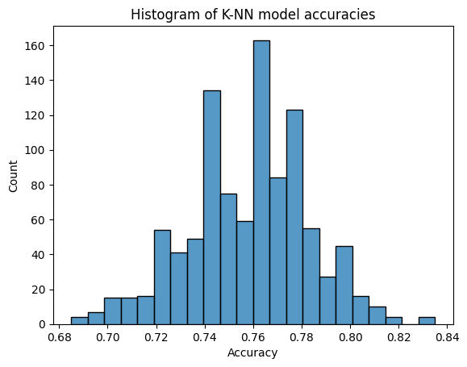

```python
plot = sns.histplot(accuracies)
plt.title('Histogram of K-NN model accuracies')
plt.xlabel('Accuracy')
```

One really common evaluation metric is **the area under the receiver operating characteristic (AUROC or AUC-ROC)**.

***Exercise 1 E)***

Explain what information you can learn about the one k-NN model you trained by using AUROC. Also, evaluate the performance by computing the metric and plotting the related curve. Draw also the line for random guesses.

- How would you interpret the results?

```python
predicted_labels_proba = knn.predict_proba(standardized_testing_features)[:,1]
roc_auc_score(testing_lables, predicted_labels_proba)
```

```
0.8894000736105998
```

```
<sklearn.metrics._plot.roc_curve.RocCurveDisplay at 0x1b5d745ba60>
```

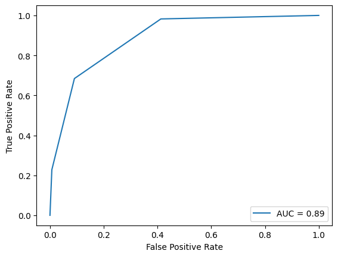

```python
fpr, tpr, threshold = roc_curve(testing_lables, predicted_labels_proba)
roc_auc = auc(fpr, tpr)
auroc_curve = RocCurveDisplay(fpr=fpr, tpr=tpr, roc_auc=roc_auc)
auroc_curve.plot()
```

## 2. Classification accuracy using leave-one-out cross validation

Even thought the train-test split gives us an unbiased estimate of the performance, we only evaluate the model one time. Especially with very small data sets, a test set will be very small. How can we be sure that the evaluation is accurate with this small test set and not just a good (or bad) luck? And what if we'd like to compare two models and the other seems to be better -- how can we be sure that it's not just a coincidence?

Well, there's a great help available and it's called **cross-validation**. This time, we'll take a look at *leave-one-out cross-validation*.

***Exercise 2 A)***

Describe *in your own words*, how leave-one-out cross validation works? How does it actually differ from the basic train-test split?

***Leave one out is one of the cross validation techniques where the number of folds are equal to the number of observations in our dataset. As the name suggests, it selects just one instance from the dataset for testing and the remaining instances are used for training of the model, this step is repeated for each instance. In genral, for the i-th instance, it uses the i-th instance for testing and every other instance (excluding the i-th) for training. On the other hand, in case of basic train-test split, we split the data once and the accuracy is also calculated one. Leave one out works the same way as the code above for 1000 train-test split, only difference being the total number of train-test split will be equal to the number of instances in the dataset and the test size will always be one.***

***Exercise 2 B)***

Let's predict once again the **presence of cardiovascular disease** using all the other variables in the dataset as features. Now, use leave-one-out cross validation to estimate the model performance. Again, use a kNN classifier with $k=3$.

- What is the classification accuracy? Compare the result with the one you got in the previous task.

*tip: Sure this could be done manually, but `cross_val_score` is quite a handy function too.*

```python
### Code - Leave-one-out cross validation
leave_one_out_cv = LeaveOneOut()

scores = cross_val_score(knn, standardized_features, labels, cv=leave_one_out_cv)
```

```python
np.mean(scores)
```

```
0.76
```

***The accuracy given by leave one out is almost similar to the 1000 differevt train-test splits. I also noticed that the accuracy given by leave one out remains same no matter how many times I re run it, whereas, in the case of 1000 different train-test splits, the accuracy changes a little bit every time I re run the code reason being it divides the data randomly. Also, in the case of single train-test split the accuray fluctuates a lot more on every run as compared to the other methods.***

## 3. Model selection with leave-one-out cross validation

So far, we've trained one model at a time and I've given the value of k for you. Accuracy is what it is (no spoilers here), but could we still do a little better? Let's try that by **hyperparameter tuning**.

This time, we're going to train multiple models, let's say 30, and choose the best K-Nearest Neighbors model among the others. Almost all models have some parameters that need to be chosen. As does the k-NN, I just happened to choose the k value of 3 for you. Note, k-NN has many other hyperparameters too, but for the sake of simplicity, this time we'll focus only on the nearest neighbors.

Now, you're supposed to find that *optimal value* for k.

***Exercise 3***

Repeat the model performance estimation with values $k=1...30$ using again leave-one-out cross validation.

- Which value of k produces the best classification accuracy?
- If the number of k is still increased, what is the limit that the classification accuracy approaches? Why?
- Can you say something about the performance of this selected model with new, unseen data? Explain, how you could you estimate the performance of this selected model.

*tip: `GridSearchCV` is a good class for this but will you get the other but the best k value out of it?*

```python
### Code - Select best k

# creating the grid
grid = GridSearchCV(KNeighborsClassifier(), {'n_neighbors': list(range(1,31))}, cv=LeaveOneOut())
# searching the best parameters
grid_search = grid.fit(standardized_training_features, training_labels)
```

```python
cv_result = pd.DataFrame(grid_search.cv_results_)
columns = ['param_n_neighbors','mean_test_score']
cv_result[columns].sort_values(columns[1], ascending=False).head(5)
```

|  | param_n_neighbors | mean_test_score |
| --- | --- | --- |
| 24 | 25 | 0.79625 |
| 26 | 27 | 0.79375 |
| 28 | 29 | 0.79250 |
| 22 | 23 | 0.79250 |
| 23 | 24 | 0.79125 |

```python
grid_search.best_params_
```

```
{'n_neighbors': 25}
```

```python
best_knn = KNeighborsClassifier(n_neighbors=25)
best_knn.fit(standardized_training_features, training_labels)
best_knn.score(standardized_testing_features, testing_lables)
```

```
0.745
```

## 4. Testing with training data (this should *never* be done out of this exercise!)

Oh, but what if we just used the ***whole data*** in training? Wouldn't we like to use as much data as possible to discover the underlying pattern in the data so why **not** to use the whole data?

*Never ever* do this out of this exercise. Why? Let's take a look.

***Exercise 4***

Repeat the previous task but use the whole data for training. Plot the resulting classification accuracy versus $k = 1...30$. Include the values from the previous task in the *same figure*.

- Comment your result and answer, why you should not test with training data?

```python
### Code - Train with whole data
results = []
for k in range(1,31):
    knn = KNeighborsClassifier(n_neighbors=k)
    knn.fit(standardized_features, labels)
    results.append(knn.score(standardized_testing_features, testing_lables))
```

```python
cv_result_all_data = pd.DataFrame({'mean_test_score': results, 'param_n_neighbors': np.arange(1,31,1)})
```

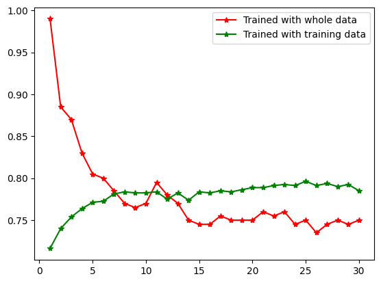

```python
plt.plot(cv_result_all_data[columns[0]], cv_result_all_data[columns[1]], marker = '*', color = 'r', label= 'Trained with whole data')

plt.plot(cv_result[columns[0]], cv_result[columns[1]], marker='*', color='g', label= 'Trained with training data')
plt.legend();
```

***When we train the model will all the data that we have, then it will result in overfitting. If the model is overfitted, it will not be able to perform classification effectively. On the other hand, if we spit data into train and test, our model will be able to generalize the patterns in the data.***

## 5. Comparison of ridge regression and kNN regression

The previous exercises were about classification. Now, we are ready to see another kind of supervised learning - regression. We're going to use **Ridge Regression** and **K-Nearest Neighbors Regression**, and compare the performances of these models.

To make this exercise more intuitively, let's change the data to another somewhat famous dataset called *The Boston Housing Dataset*. The Boston Housing Dataset is a derived from information collected by the U.S. Census Service concerning housing in the area of Boston, Massachusetts. Let's have a quick peek at the variables:

- **CRIM** - per capita crime rate by town
- **ZN** - proportion of residential land zoned for lots over 25,000 sq.ft.
- **INDUS** - proportion of non-retail business acres per town.
- **CHAS** - Charles River dummy variable (1 if tract bounds river; 0 otherwise)
- **NOX** - nitric oxides concentration (parts per 10 million)
- **RM** - average number of rooms per dwelling
- **AGE** - proportion of owner-occupied units built prior to 1940
- **DIS** - weighted distances to five Boston employment centres
- **RAD** - index of accessibility to radial highways
- **TAX** - full-value property-tax rate per $10,000
- **PTRATIO** - pupil-teacher ratio by town
- **B** - 1000(Bk - 0.63)^2 where Bk is the proportion of blacks by town
- **LSTAT** - % lower status of the population
- **MEDV** - Median value of owner-occupied homes in $1000's

No worries if the variables don't make a lot of sense. However, the object is to predict **the median house value**. So the target variable is now **MEDV** and all the others are **features**.

There's the code chunk for loading data provided again. Again, the data file should be located in the same directory as this notebook file!

```python
### Loading code provided
# ------------------------------------------------------
# The data file should be at the same location than the
# exercise file to make sure the following lines work!
# Otherwise, fix the path.
# ------------------------------------------------------

# Data path
data_path = 'ex2_boston_housing_data.csv'

# Load the data
boston_data = pd.read_csv(data_path, dtype='float')

boston_features = boston_data.drop('MEDV', axis=1)
boston_labels = boston_data['MEDV']
```

With regression, we can examine **the relationship between two or more variables**. This relationship is represented by an *equation*, which itself represents how much y changes with any given change of x. So for example, we could use *age* as an independent variable to predict *height* (a dependent variable).

We start by looking at the relationships between the variables in the given dataset.

***Exercise 5 A)***

Make scatter plots where you present each feature versus the target variable `MEDV`.

- What can you say about the relationships?

*tip: seaborn.pairplot is quite a handy function where you can set x_vars and y_vars to point out the variables you need*

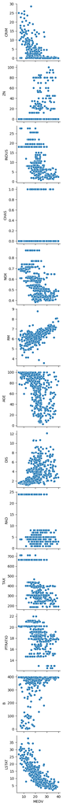

```python
### Code - Scatter plots
sns.pairplot(data=boston_data, x_vars=['MEDV'], y_vars=boston_features.columns)
```

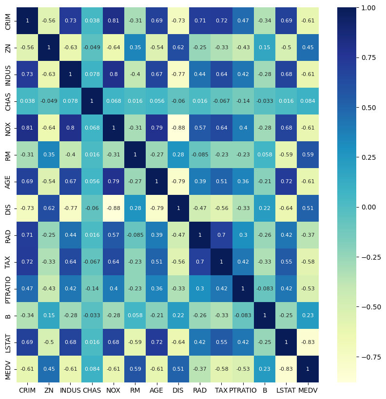

```python
fig, ax = plt.subplots(figsize=(10,10))
sns.heatmap(data=boston_data.corr(method='spearman'), cmap="YlGnBu", annot=True, annot_kws={"size": 8}, ax=ax)
```

*MEDV has:  
1. Strong negative correlation with LSTAT  
2. Moderate negative correlation with PTRATIO, TAX, AGE, NOX, INDUS and CRIM (CRIM INDUS, NOX and AGE, all have correlation of -0.61)  
3. Moderate positive correlation with DIS, RM and ZN  
4. Low positive correlation with B and low negative correlation with RAD  
5. Almost no correlation with CHAS*

We are about to compare two different regression models. We need to be sure that both are *the best models* among the other trained models. But to make sure that these selected models really are the best ones, we're going to use a combination of cross-validation and hyperparameter tuning right away. What's the other way to ensure that the chosen hyperparameters are appropriate for the given data?

For the k-Nearest neighbors, we have previously get familiar with the optimization of the k value. Let's continue with this value to find the *optimal k* for the k-nearest neighbors regression too. With ridge regression, we have this hyperparameter called $\lambda$ (read as 'lambda'). We'll use this parameter for model selection.

To compare the models, let's use a loss function called **mean absolute error (MAE)**.

***Exercise 5 B)***

Do you need to prepare the data a little? Explain your decision.

```python
boston_data.describe()
```

|  | CRIM | ZN | INDUS | CHAS | NOX | RM | AGE | DIS | RAD | TAX | PTRATIO | B | LSTAT | MEDV |
| --- | --- | --- | --- | --- | --- | --- | --- | --- | --- | --- | --- | --- | --- | --- |
| count | 467.000000 | 467.000000 | 467.000000 | 467.000000 | 467.000000 | 467.000000 | 467.000000 | 467.000000 | 467.000000 | 467.000000 | 467.000000 | 467.000000 | 467.000000 | 467.000000 |
| mean | 2.859473 | 10.825482 | 11.178758 | 0.059957 | 0.554025 | 6.203176 | 68.283084 | 3.861389 | 9.400428 | 407.528908 | 18.581799 | 357.492741 | 13.047259 | 21.113490 |
| std | 5.204950 | 22.435436 | 6.810618 | 0.237662 | 0.117089 | 0.591121 | 28.062858 | 2.113944 | 8.657791 | 167.120323 | 2.061196 | 89.711000 | 6.872562 | 6.656016 |
| min | 0.006320 | 0.000000 | 0.740000 | 0.000000 | 0.385000 | 3.561000 | 2.900000 | 1.137000 | 1.000000 | 187.000000 | 12.600000 | 0.320000 | 1.980000 | 5.600000 |
| 25% | 0.082100 | 0.000000 | 5.190000 | 0.000000 | 0.449000 | 5.879500 | 44.700000 | 2.122300 | 4.000000 | 281.000000 | 17.400000 | 375.955000 | 7.580000 | 16.800000 |
| 50% | 0.228760 | 0.000000 | 9.690000 | 0.000000 | 0.538000 | 6.169000 | 76.700000 | 3.317500 | 5.000000 | 330.000000 | 19.100000 | 392.110000 | 11.980000 | 20.800000 |
| 75% | 3.504645 | 12.500000 | 18.100000 | 0.000000 | 0.624000 | 6.539000 | 93.850000 | 5.266000 | 24.000000 | 666.000000 | 20.200000 | 396.900000 | 17.115000 | 24.350000 |
| max | 28.655800 | 100.000000 | 27.740000 | 1.000000 | 0.871000 | 8.780000 | 100.000000 | 12.126500 | 24.000000 | 711.000000 | 22.000000 | 396.900000 | 37.970000 | 39.800000 |

```python
### Code - Preparation

# splitting training and testing data
X_train, X_test, y_train, y_test = train_test_split(boston_features, boston_labels, test_size=0.2)
```

```python
# storing the index of the splitted data
X_train_index = X_train.index
X_test_index = X_test.index

# scaling the data
STD_scaler = StandardScaler()
X_train = pd.DataFrame(STD_scaler.fit_transform(X_train), columns=X_train.columns)
X_test = pd.DataFrame(STD_scaler.fit_transform(X_test), columns=X_test.columns)

# assigning the index back
X_train.set_index(X_train_index, inplace=True)
X_test.set_index(X_test_index, inplace=True)
```

***Since the all the features have differernt scale, it is important to standardize data before performing analysis***

***Exercise 5 C)***

Then, train a ridge regression model and a k-NN regression model. For hyperparameters, use $\lambda=2^{-10}...2^{10}$ and $k=1...30$. Once again, use leave-one-out cross validation.

- What are the total performances of each model and how they compare with each other?
- What does the MAE tell you about the performances of your models and in general?

*note: In a `sklearn.linear_model.Ridge` class, lambda is called alpha so don't get confused*

```python
### Code - Ridge regression and k-NN regression

# 1. ridge regression

grid = GridSearchCV(Ridge(), {'alpha': [2**i for i in range(-10,11)]}, cv=LeaveOneOut(), scoring='neg_mean_squared_error')
grid_search = grid.fit(X_train, y_train)
```

```python
ridge_reg_cv_result = pd.DataFrame(grid_search.cv_results_)
rr_columns = ['param_alpha', 'mean_test_score']
ridge_reg_cv_result[rr_columns].sort_values('mean_test_score', ascending=False).head()
```

|  | param_alpha | mean_test_score |
| --- | --- | --- |
| 12 | 4 | -11.776573 |
| 13 | 8 | -11.777302 |
| 11 | 2 | -11.784571 |
| 10 | 1 | -11.791758 |
| 9 | 0.5 | -11.796358 |

```python
grid_search.best_params_
```

```
{'alpha': 4}
```

```python
ridge_reg = Ridge(alpha=4)
ridge_reg.fit(X_train, y_train)
ridge_reg.score(X_test, y_test)
```

```
0.7364709423057276
```

```python
ridge_pred = ridge_reg.predict(X_test)
mean_absolute_error(y_test, ridge_pred)
```

```
2.6096202217775786
```

```python
# 2 knn regression

grid2 = GridSearchCV(KNeighborsRegressor(), {'n_neighbors': list(range(1,31))}, cv=LeaveOneOut(), scoring='neg_mean_absolute_error')
grid_search2 = grid2.fit(X_train, y_train)
```

```python
knn_reg_cv_result = pd.DataFrame(grid_search2.cv_results_)
knn_columns = ['param_n_neighbors', 'mean_test_score']
knn_reg_cv_result[knn_columns].sort_values('mean_test_score', ascending=False).head()
```

|  | param_n_neighbors | mean_test_score |
| --- | --- | --- |
| 2 | 3 | -2.111260 |
| 1 | 2 | -2.161260 |
| 3 | 4 | -2.167761 |
| 5 | 6 | -2.194951 |
| 4 | 5 | -2.197909 |

```python
grid_search2.best_params_
```

```
{'n_neighbors': 3}
```

```python
knn_reg = KNeighborsRegressor(n_neighbors=3)
knn_reg.fit(X_train, y_train)
knn_reg.score(X_test, y_test)
```

```
0.7689261850193138
```

```python
knn_reg_pred = knn_reg.predict(X_test)
mean_absolute_error(y_test, knn_reg_pred)
```

```
2.198581560283688
```

We can say something about the performance now. One way to do the visualization is to plot actual labels vs predicted labels. Let's do that.

***Exercise 5 D)***

Using the best models found in the previous exercise, plot the actual labels vs. predicted labels.

- How did the selected models perform?
- In an ideal situation, where should the data points be located?

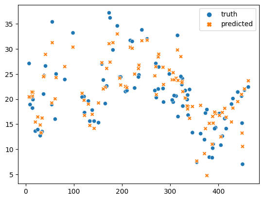

```python
### Code - Plot actual vs predicted labels

# 1 Ridge regression plotting

ridge_reg_plot = pd.DataFrame({'truth': y_test , 'predicted': ridge_pred})
sns.scatterplot(data=ridge_reg_plot)
```

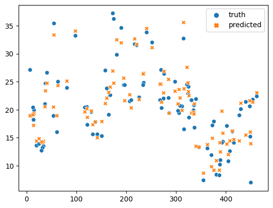

```python
# 2 Ridge regression plotting

knn_reg_plot = pd.DataFrame({'truth': y_test , 'predicted': knn_reg_pred})
sns.scatterplot(data=knn_reg_plot)
```

*1. Knn performed better than ridge regression, as we can see in the plot that the predicted values are closer from the actual values in the case of knn.  
2. In an ideal situation, the predicted values must be as closer to the actual values as they can be.*

## BONUS: Feature selection - most useful features in predicting the disease

You can stop here and get the "pass" grade! To get the "pass with honors" grade, you need to do the following exercise. This means you'll get one bonus point for the exam.

The exercise is not as straightforward as the previous ones, and may require you to do some research of your own. You are also required to **explain** the steps you choose with your own words, and show that you tried to understand the idea behind the task. There's no single correct solution for this so just explain me what you did and why you did it.

Unfortunately, due to the lack of resources and time, doctors are not able to measure all the values represented in the given dataset. Luckily, keen students are ready to help: You should now find **five [5] most useful features** in predicting the presence of the cardiovascular disease among the ones in the given cardio data set.

Use the selected features to train and test a model of your choice. Evaluate the performance by computing the accuracy and drawing a ROC curve. Remember not to use any information from the test set when selecting the features!

**Discuss** your results.

```python
from sklearn.feature_selection import SelectKBest
from sklearn.feature_selection import f_classif

# finding the top 5 features using the training set

fs = SelectKBest(score_func=f_classif, k=5)
fs.fit_transform(standardized_training_features, training_labels)
selected_features = standardized_training_features.columns[fs.get_support()]

selected_features
```

```
Index(['age', 'ap_hi', 'ap_lo', 'cholesterol_elevated', 'cholesterol_normal'], dtype='object')
```

***I have used SelectKBest class with f_classif as the score function to find the top 5 features. The top 5 features are ['age', 'ap_hi', 'ap_lo', 'cholesterol_elevated', 'cholesterol_normal']***

```python
# selecting the top 5 features
selected_training_features = standardized_training_features[selected_features]
selected_testing_features = standardized_testing_features[selected_features]
```

```python
grid_n = GridSearchCV(KNeighborsClassifier(), param_grid={'n_neighbors': list(range(1,31))}, cv=LeaveOneOut())
grid_n.fit(selected_training_features, training_labels)
```

```
GridSearchCV(cv=LeaveOneOut(), estimator=KNeighborsClassifier(),
             param_grid={'n_neighbors': [1, 2, 3, 4, 5, 6, 7, 8, 9, 10, 11, 12,
                                         13, 14, 15, 16, 17, 18, 19, 20, 21, 22,
                                         23, 24, 25, 26, 27, 28, 29, 30]})
```

```python
grid_n.best_params_
```

```
{'n_neighbors': 22}
```

```python
best_classif = KNeighborsClassifier(n_neighbors=22)
best_classif.fit(selected_training_features, training_labels)
best_classif.score(selected_testing_features, testing_lables)
```

```
0.73
```

***The model got a score of 73% using the 5 most important features. Therefore, we can say that the other remaining features are not as important in making the prediction***

```python
predicted_labels_proba = best_classif.predict_proba(selected_testing_features)[:,1]
roc_auc_score(testing_lables, predicted_labels_proba)
```

```
0.7910685805422648
```

```
<sklearn.metrics._plot.roc_curve.RocCurveDisplay at 0x1b5d7337be0>
```

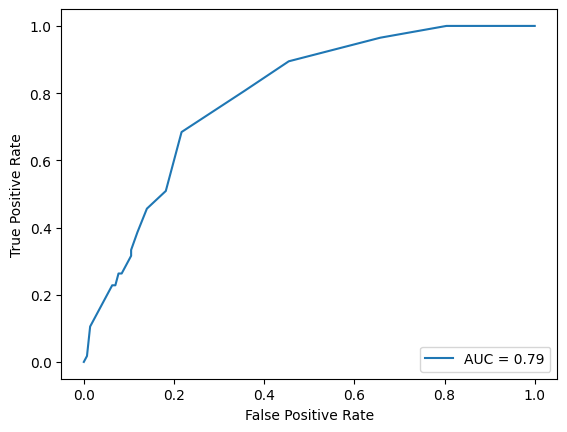

```python
fpr, tpr, threshold = roc_curve(testing_lables, predicted_labels_proba)
roc_auc = auc(fpr, tpr)
auroc_curve = RocCurveDisplay(fpr=fpr, tpr=tpr, roc_auc=roc_auc)
auroc_curve.plot()
```

***The AUC is 0.79, which means the model is not making random guesses and is good at seprating the classes from one another.***

***I think feature selecting is useful in reducing the time and space complexity of our code and at the same time maintains the accuracy***